# Malle ERW — Bayesian C and d14C pool predictions (plot-only)

Saved five-predictor submodels: observed-versus-predicted plots, relative predictor importance and coefficient tables

## Construction of Bayesian C and d¹⁴C models

The Bayesian C and d¹⁴C models were constructed using the integrated geochemical dataset (`integrated_geochemistry_for_bayesian.csv`) to fit eight separate regularised multiple-regression models for bulk soil, MAOM, oPOM and fPOM carbon concentrations and their corresponding 2026 Δ¹⁴C values. Candidate geochemical predictors were filtered for sufficient data availability (≥70% observed values), median-imputed, standardised, and screened to reduce severe multicollinearity (|r| > 0.95). Both predictors and responses were standardised for model fitting. Each model was specified as a Gaussian regression in Stan, with normally distributed slope priors (Normal(0, 0.5)), a Normal(0, 1) intercept prior and an exponential prior on the residual standard deviation. Models were fitted using four-chain MCMC via CmdStanR. Projection predictive variable selection (projpred) was then used to identify reduced predictor sets, which were independently refitted as three-, four- and five-predictor Bayesian models.

This plot-only document loads the saved five-predictor model predictions and coefficient summaries. It does not refit any Bayesian models.

## Interpretation of model diagnostics and coefficient summaries

The Bayesian models quantify associations between soil geochemical properties and carbon (C) and radiocarbon (d¹⁴C) responses across treatments. Posterior coefficient summaries (mean, median, standard deviation, and 95% credible intervals) are used to evaluate the direction, magnitude, and uncertainty of predictor associations and to assess proposed carbon stabilisation mechanisms. Because predictors are standardised, coefficients represent the expected change in the response, in its original units, associated with a one-standard-deviation increase in a predictor, conditional on the other predictors. Credible intervals that exclude zero and high posterior probabilities of a positive (`Pr_positive`) or negative (`Pr_negative`) coefficient indicate stronger evidence for an association in the corresponding direction, whereas intervals spanning zero indicate greater uncertainty in the direction of the effect. These associations should be interpreted as conditional relationships rather than causal effects.

Relative predictor importance is calculated from the absolute posterior mean standardised coefficients. Each predictor’s absolute coefficient is expressed as a percentage of the sum of the absolute coefficients of all five predictors in the corresponding model. These percentages describe the relative magnitude of the fitted standardised associations within each model; they do not represent causal contributions or independent variance explained. The direction of each association is retained in the coefficient summary tables.

## Load saved model predictions and coefficient summaries

```r
library(tidyverse)
library(here)
library(knitr)
library(patchwork)

out_dir <- here::here("outputs", "bayesian_C_d14C_predictions_withftir")
table_dir <- file.path(out_dir, "tables")
plot_dir <- file.path(out_dir, "plots")

responses <- c(
  "C_Bulk", "C_MAOM", "C_oPOM", "C_fPOM",
  "d14C_2026_Bulk", "d14C_2026_MAOM",
  "d14C_2026_oPOM", "d14C_2026_fPOM"
)

safe_name <- function(x) {
  x %>%
    str_replace_all("[^A-Za-z0-9]+", "_") %>%
    str_replace_all("^_|_$", "")
}

five_predictor_prediction_file <- function(response) {
  file.path(
    table_dir,
    paste0(
      "predictions_",
      safe_name(response),
      "__projpred_5predictors.csv"
    )
  )
}

five_predictor_coefficient_file <- function(response) {
  file.path(
    table_dir,
    paste0(
      "coefficients_",
      safe_name(response),
      "__projpred_5predictors.csv"
    )
  )
}

missing_predictions <- responses[
  !file.exists(map_chr(responses, five_predictor_prediction_file))
]

missing_coefficients <- responses[
  !file.exists(map_chr(responses, five_predictor_coefficient_file))
]

if (length(missing_predictions)) {
  warning(
    "Prediction CSVs not found for: ",
    paste(missing_predictions, collapse = ", ")
  )
}

if (length(missing_coefficients)) {
  warning(
    "Coefficient CSVs not found for: ",
    paste(missing_coefficients, collapse = ", ")
  )
}

available_responses <- responses[
  file.exists(map_chr(responses, five_predictor_prediction_file))
]

available_coefficient_responses <- responses[
  file.exists(map_chr(responses, five_predictor_coefficient_file))
]

if (length(available_responses) == 0L) {
  stop(
    "No five-predictor prediction CSVs found in: ",
    table_dir,
    ". Expected files like predictions_C_Bulk__projpred_5predictors.csv"
  )
}

if (!dir.exists(plot_dir)) {
  dir.create(plot_dir, recursive = TRUE)
}
```

## Relative importance calculation

The function below identifies the predictor-name column and standardised coefficient column in each saved coefficient CSV.

```r
identify_standardised_coefficient_column <- function(coef_tbl) {

  nms <- names(coef_tbl)

  # The saved Estimate column contains the posterior mean
  # coefficients from the model fitted using standardised
  # predictors AND standardised responses.
  if ("Estimate" %in% nms) {
    return("Estimate")
  }

  if ("mean_standardized" %in% nms) {
    return("mean_standardized")
  }

  if ("mean_standardised" %in% nms) {
    return("mean_standardised")
  }

  if ("mean_std" %in% nms) {
    return("mean_std")
  }

  if ("beta_std" %in% nms) {
    return("beta_std")
  }

  stop(
    "Could not identify the standardised coefficient column. ",
    "Available columns: ",
    paste(nms, collapse = ", ")
  )
}


# Identify the posterior mean of the standardised coefficient.
identify_standardised_coefficient_column <- function(coef_tbl) {

  nms <- names(coef_tbl)

  # Explicitly named standardised coefficient columns are preferred.
  preferred <- c(
    "mean_standardized",
    "mean_standardised",
    "mean_std",
    "standardized_mean",
    "standardised_mean",
    "estimate_standardized",
    "estimate_standardised",
    "estimate_std",
    "beta_standardized",
    "beta_standardised",
    "beta_std",
    "standardized_coefficient",
    "standardised_coefficient",
    "mean_standardized_response",
    "mean_standardised_response"
  )

  found <- preferred[preferred %in% nms]

  if (length(found) > 0L) {
    return(found[1])
  }

  # Also allow alternative naming conventions containing
  # standardised/std and mean/estimate/coefficient.
  standardised_candidates <- nms[
    str_detect(
      tolower(nms),
      "(standard|standardised|standardized|std).*(mean|estimate|coef|beta)|(mean|estimate|coef|beta).*(standard|standardised|standardized|std)"
    )
  ]

  if (length(standardised_candidates) > 0L) {
    return(standardised_candidates[1])
  }

  # Fallback: the ordinary posterior mean is used when the
  # coefficient CSV also contains separately labelled original-
  # response coefficients, or when no alternative mean exists.
  if ("mean" %in% nms) {
    return("mean")
  }

  if ("median" %in% nms) {
    return("median")
  }

  stop(
    "Could not identify a standardised coefficient column. Available columns: ",
    paste(nms, collapse = ", "),
    ". Please check the coefficient CSV structure."
  )
}

identify_predictor_column <- function(coef_tbl) {

  possible_columns <- c(
    "term",
    "Predictor",
    "predictor",
    "variable",
    "Variable",
    "parameter",
    "Parameter",
    "covariate",
    "Covariate"
  )

  found_column <- possible_columns[
    possible_columns %in% names(coef_tbl)
  ]

  if (length(found_column) == 0) {
    stop(
      "Could not identify the predictor column. Available columns: ",
      paste(names(coef_tbl), collapse = ", ")
    )
  }

  found_column[1]
}


identify_standardised_coefficient_column <- function(coef_tbl) {

  possible_columns <- c(
    "Estimate",
    "mean_standardized",
    "mean_standardised",
    "mean_std",
    "beta_std"
  )

  found_column <- possible_columns[
    possible_columns %in% names(coef_tbl)
  ]

  if (length(found_column) == 0) {
    stop(
      "Could not identify the standardised coefficient column. ",
      "Available columns: ",
      paste(names(coef_tbl), collapse = ", ")
    )
  }

  found_column[1]
}


calculate_relative_importance <- function(coef_tbl, response) {

  predictor_col <- identify_predictor_column(coef_tbl)

  coefficient_col <- identify_standardised_coefficient_column(coef_tbl)

  importance_tbl <- coef_tbl %>%
    transmute(
      Predictor = as.character(.data[[predictor_col]]),
      Standardised_coefficient = as.numeric(.data[[coefficient_col]])
    ) %>%
    filter(
      !is.na(Predictor),
      !is.na(Standardised_coefficient)
    ) %>%
    filter(
      !str_detect(
        tolower(Predictor),
        "intercept|^alpha$|^sigma$|residual|^lp__$"
      )
    )

  if (nrow(importance_tbl) != 5L) {
    stop(
      "Expected exactly five predictor coefficients for ",
      response,
      ", but found ",
      nrow(importance_tbl),
      ". Check the coefficient CSV."
    )
  }

  total_absolute_coefficient <- sum(
    abs(importance_tbl$Standardised_coefficient)
  )

  if (!is.finite(total_absolute_coefficient) ||
      total_absolute_coefficient == 0) {
    stop(
      "Cannot calculate relative importance for ",
      response,
      ": total absolute standardised coefficient is zero or invalid."
    )
  }

  importance_tbl %>%
    mutate(
      Relative_importance =
        abs(Standardised_coefficient) /
        total_absolute_coefficient * 100
    ) %>%
    arrange(Relative_importance) %>%
    mutate(
      Predictor = factor(
        Predictor,
        levels = Predictor
      )
    )
}
# Calculate relative importance from the five standardised coefficients.

calculate_relative_importance <- function(coef_tbl, response) {

  predictor_col <- identify_predictor_column(coef_tbl)
  coefficient_col <- identify_standardised_coefficient_column(coef_tbl)

  importance_tbl <- coef_tbl %>%
    transmute(
      Predictor = as.character(.data[[predictor_col]]),
      Standardised_coefficient = as.numeric(.data[[coefficient_col]])
    ) %>%
    filter(
      !is.na(Predictor),
      !is.na(Standardised_coefficient)
    ) %>%
    filter(
      !str_detect(
        tolower(Predictor),
        "intercept|^alpha$|^sigma$|residual|^lp__$"
      )
    )

  if (nrow(importance_tbl) != 5L) {
    stop(
      "Expected exactly five predictor coefficients for ",
      response,
      ", but found ",
      nrow(importance_tbl),
      ". Check the coefficient CSV."
    )
  }

  total_absolute_coefficient <- sum(
    abs(importance_tbl$Standardised_coefficient)
  )

  if (!is.finite(total_absolute_coefficient) ||
      total_absolute_coefficient == 0) {
    stop(
      "Cannot calculate relative importance for ",
      response,
      ": total absolute standardised coefficient is zero or invalid."
    )
  }

  importance_tbl %>%
    mutate(
      Relative_importance = (
        abs(Standardised_coefficient) /
          total_absolute_coefficient
      ) * 100
    ) %>%
    arrange(Relative_importance) %>%
    mutate(
      Predictor = factor(
        Predictor,
        levels = Predictor
      )
    )
}
```

## Five-predictor model observed-versus-predicted plots

The plotted CSVs contain the saved observed values, posterior predicted means, 95% fitted-mean credible intervals, and 95% posterior predictive intervals. These are in-sample fitted predictions, not external validation.

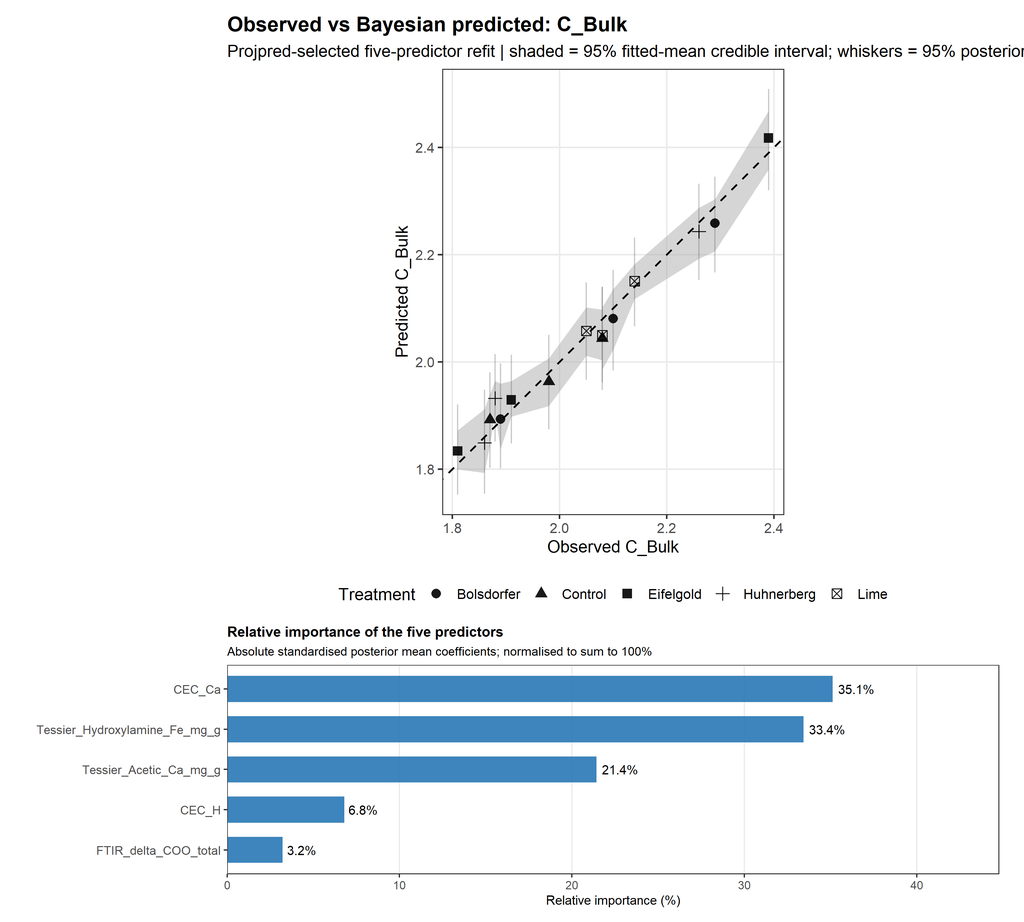

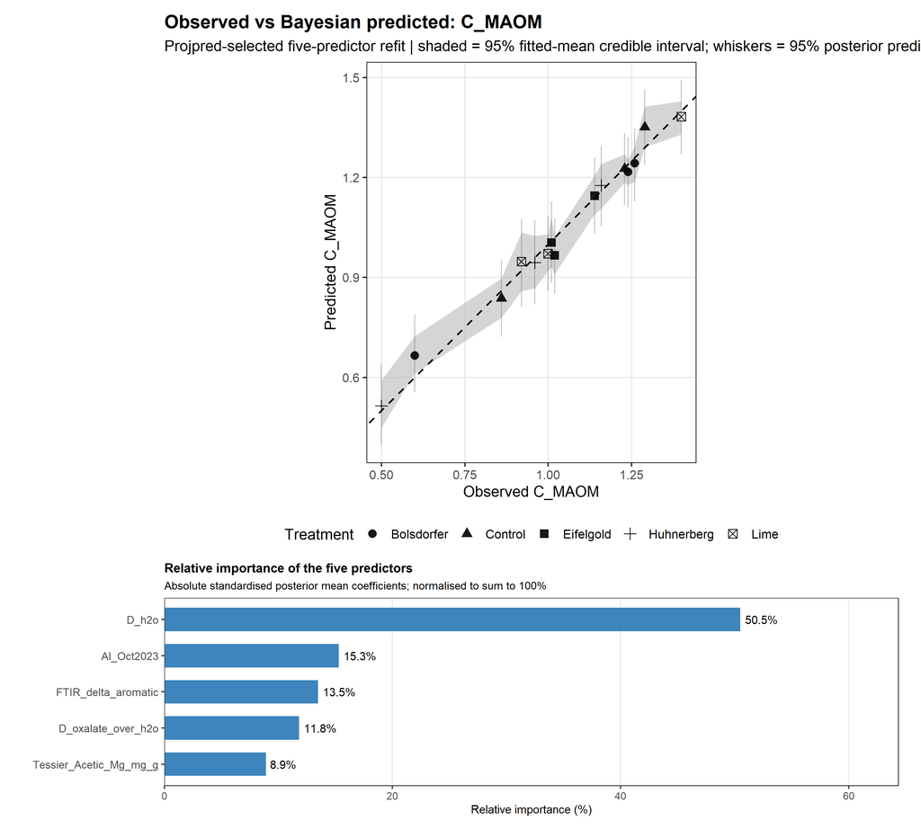

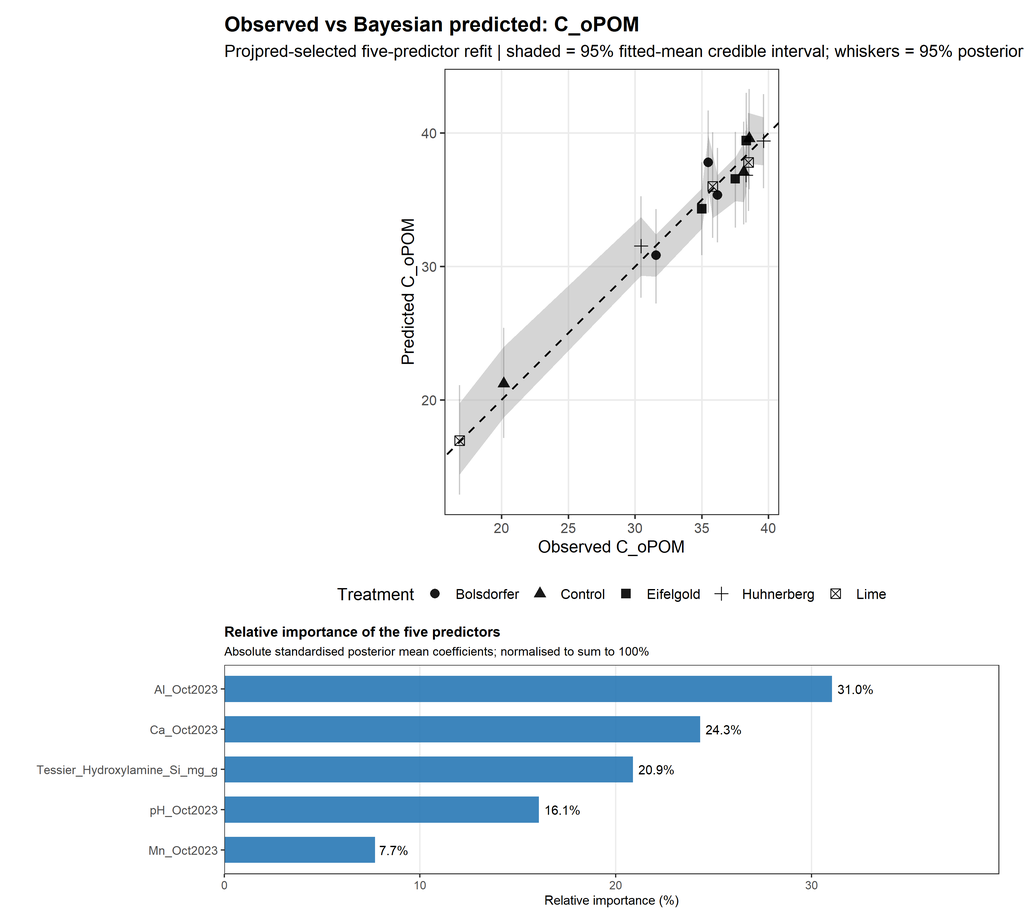

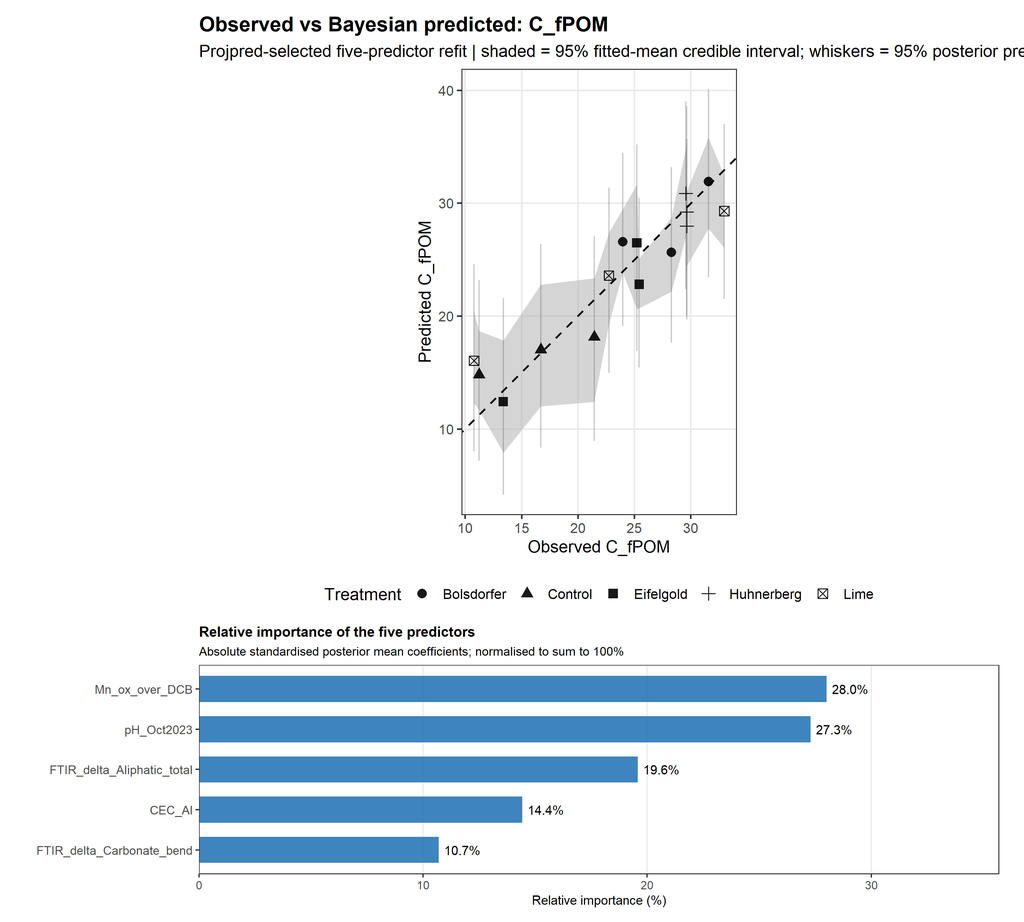

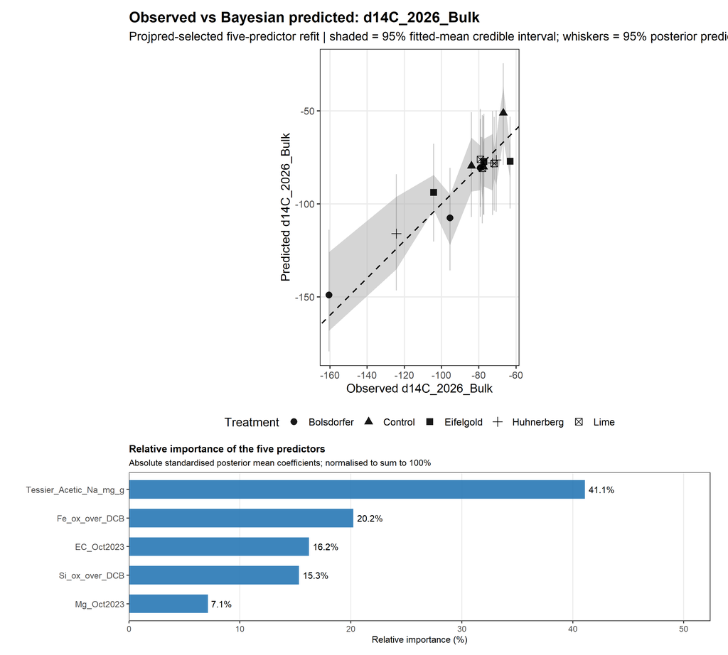

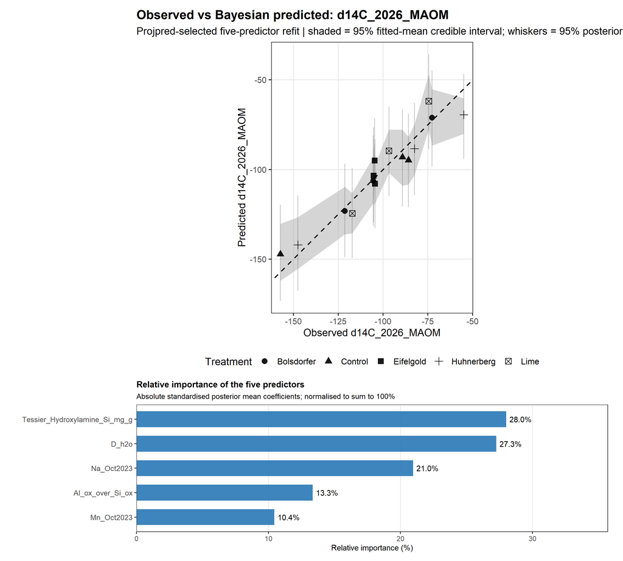

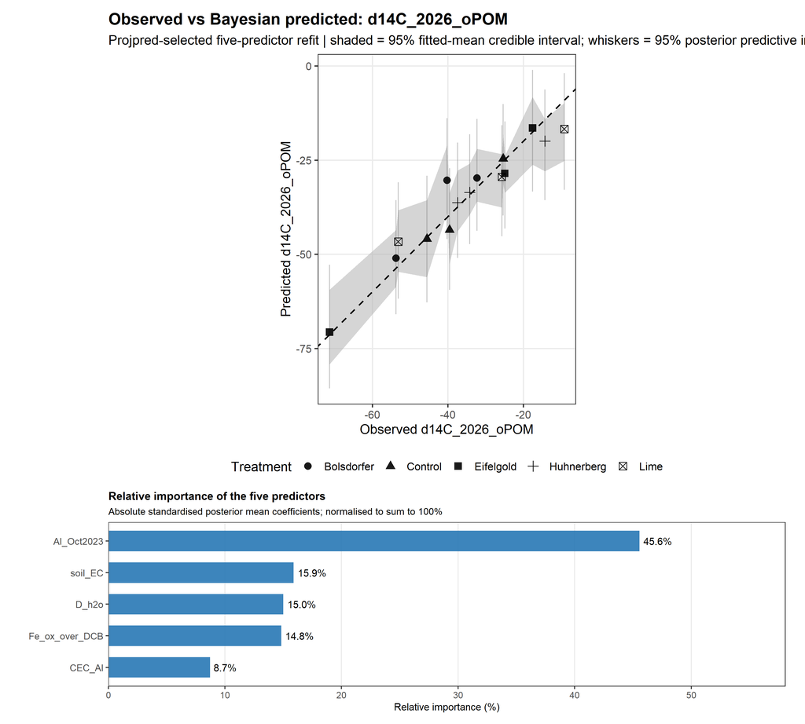

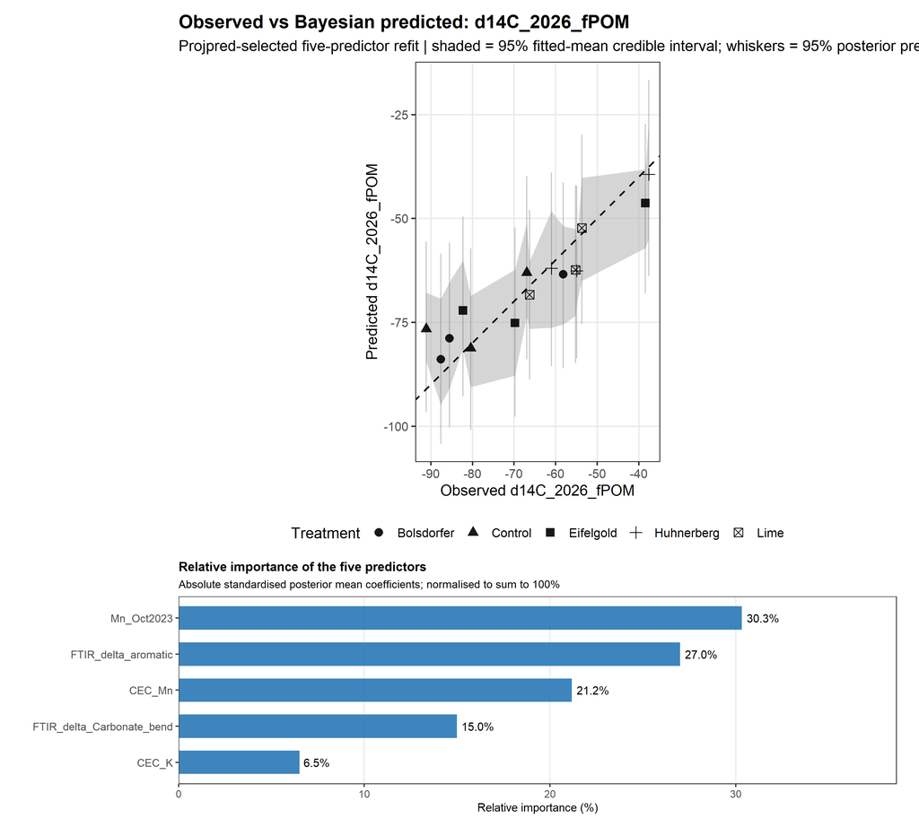

```r
plot_observed_predicted_saved <- function(pred, response) {

  required <- c(
    "observed",
    "predicted_mean",
    "fitted_lower_95",
    "fitted_upper_95",
    "predictive_lower_95",
    "predictive_upper_95",
    "Treatment_model"
  )

  absent <- setdiff(required, names(pred))

  if (length(absent)) {
    stop(
      "Missing required prediction columns for ",
      response,
      ": ",
      paste(absent, collapse = ", ")
    )
  }

  pred <- pred %>%
    arrange(observed) %>%
    mutate(row_order = row_number())

  ggplot(
    pred,
    aes(x = observed, y = predicted_mean)
  ) +
    geom_ribbon(
      aes(
        ymin = fitted_lower_95,
        ymax = fitted_upper_95
      ),
      fill = "grey70",
      alpha = 0.55
    ) +
    geom_errorbar(
      aes(
        ymin = predictive_lower_95,
        ymax = predictive_upper_95
      ),
      width = 0,
      alpha = 0.35,
      colour = "grey40"
    ) +
    geom_point(
      aes(shape = Treatment_model),
      size = 2.8,
      alpha = 0.9
    ) +
    geom_abline(
      intercept = 0,
      slope = 1,
      linetype = "dashed",
      linewidth = 0.7,
      colour = "black"
    ) +
    coord_equal() +
    labs(
      title = paste("Observed vs Bayesian predicted:", response),
      subtitle = paste(
        "Projpred-selected five-predictor refit |",
        "shaded = 95% fitted-mean credible interval;",
        "whiskers = 95% posterior predictive interval"
      ),
      x = paste("Observed", response),
      y = paste("Predicted", response),
      shape = "Treatment"
    ) +
    theme_bw(base_size = 12) +
    theme(
      plot.title = element_text(face = "bold"),
      legend.position = "bottom",
      panel.grid.minor = element_blank()
    )
}


# Mini horizontal bar plot of relative predictor importance.
plot_relative_importance <- function(importance_tbl, response) {

  ggplot(
    importance_tbl,
    aes(
      x = Relative_importance,
      y = Predictor
    )
  ) +
    geom_col(
      fill = "#2878B5",
      width = 0.65,
      alpha = 0.9
    ) +
    geom_text(
      aes(
        label = sprintf("%.1f%%", Relative_importance)
      ),
      hjust = -0.15,
      size = 3.2
    ) +
    scale_x_continuous(
      limits = c(
        0,
        max(importance_tbl$Relative_importance) * 1.25
      ),
      expand = expansion(mult = c(0, 0.02))
    ) +
    labs(
      title = "Relative importance of the five predictors",
      subtitle = paste(
        "Absolute standardised posterior mean coefficients;",
        "normalised to sum to 100%"
      ),
      x = "Relative importance (%)",
      y = NULL
    ) +
    theme_bw(base_size = 10) +
    theme(
      plot.title = element_text(
        face = "bold",
        size = 10
      ),
      plot.subtitle = element_text(size = 8.5),
      axis.text.y = element_text(size = 8.5),
      axis.text.x = element_text(size = 8),
      axis.title.x = element_text(size = 9),
      panel.grid.major.y = element_blank(),
      panel.grid.minor = element_blank(),
      plot.margin = margin(
        t = 2,
        r = 12,
        b = 5,
        l = 5
      )
    )
}


# Load saved prediction and coefficient CSVs, combine plots,
# display them in the HTML document, and save them as PNG files.
for (response in available_responses) {

  pred <- readr::read_csv(
    five_predictor_prediction_file(response),
    show_col_types = FALSE
  )

  observed_plot <- plot_observed_predicted_saved(
    pred,
    response
  )

  if (response %in% available_coefficient_responses) {

    coef_tbl <- readr::read_csv(
      five_predictor_coefficient_file(response),
      show_col_types = FALSE
    )

    importance_tbl <- calculate_relative_importance(
      coef_tbl,
      response
    )

    importance_plot <- plot_relative_importance(
      importance_tbl,
      response
    )

    combined_plot <- observed_plot /
      importance_plot +
      plot_layout(
        heights = c(3.2, 1.5)
      )

  } else {

    warning(
      "No coefficient CSV found for ",
      response,
      ". Showing observed-versus-predicted plot only."
    )

    combined_plot <- observed_plot
  }

  print(combined_plot)

  ggsave(
    filename = file.path(
      plot_dir,
      paste0(
        "Observed_vs_Predicted_with_Relative_Importance_",
        safe_name(response),
        ".png"
      )
    ),
    plot = combined_plot,
    width = 10,
    height = 9,
    dpi = 300,
    bg = "white"
  )
}
```

## Coefficient summaries — five-predictor models

Each table is loaded directly from its corresponding saved coefficient CSV. The original-response coefficient columns and credible intervals are retained as supplied by the model-fitting script.

```r
if (length(available_coefficient_responses) == 0L) {

  cat(
    "**No five-predictor coefficient summary CSVs were found in:** `",
    table_dir,
    "`",
    sep = ""
  )

} else {

  for (response in available_coefficient_responses) {

    coef_tbl <- readr::read_csv(
      five_predictor_coefficient_file(response),
      show_col_types = FALSE
    )

    cat("\n\n### ", response, "\n\n", sep = "")

    cat(
      knitr::kable(
        coef_tbl,
        format = "html",
        digits = 3,
        caption = paste(
          "Saved coefficient summary —",
          response,
          "(projpred-selected five-predictor refit)"
        ),
        table.attr = 'class="table table-striped table-hover"'
      )
    )

    cat("\n\n")
  }
}
```

### C_Bulk

Saved coefficient summary — C_Bulk (projpred-selected five-predictor refit)

| term | Estimate | Est.Error | Q2.5 | Q50 | Q97.5 | prob_positive | prob_negative | response | model | n_predictors | predictors | estimate_original_response_per_predictor_SD | lower_original_response_per_predictor_SD | upper_original_response_per_predictor_SD |
| --- | --- | --- | --- | --- | --- | --- | --- | --- | --- | --- | --- | --- | --- | --- |
| Intercept | 0.001 | 0.056 | -0.109 | 0.001 | 0.115 | 0.506 | 0.494 | C_Bulk | 5-predictor refit | 5 | CEC_Ca + Tessier_Hydroxylamine_Fe_mg_g + Tessier_Acetic_Ca_mg_g + CEC_H + FTIR_delta_COO_total | 0.000 | -0.019 | 0.020 |
| CEC_Ca | 0.998 | 0.094 | 0.797 | 1.001 | 1.176 | 1.000 | 0.000 | C_Bulk | 5-predictor refit | 5 | CEC_Ca + Tessier_Hydroxylamine_Fe_mg_g + Tessier_Acetic_Ca_mg_g + CEC_H + FTIR_delta_COO_total | 0.176 | 0.140 | 0.207 |
| Tessier_Hydroxylamine_Fe_mg_g | -0.950 | 0.097 | -1.127 | -0.957 | -0.735 | 0.000 | 1.000 | C_Bulk | 5-predictor refit | 5 | CEC_Ca + Tessier_Hydroxylamine_Fe_mg_g + Tessier_Acetic_Ca_mg_g + CEC_H + FTIR_delta_COO_total | -0.167 | -0.198 | -0.129 |
| Tessier_Acetic_Ca_mg_g | 0.609 | 0.100 | 0.403 | 0.613 | 0.801 | 1.000 | 0.000 | C_Bulk | 5-predictor refit | 5 | CEC_Ca + Tessier_Hydroxylamine_Fe_mg_g + Tessier_Acetic_Ca_mg_g + CEC_H + FTIR_delta_COO_total | 0.107 | 0.071 | 0.141 |
| CEC_H | -0.193 | 0.062 | -0.311 | -0.194 | -0.065 | 0.004 | 0.996 | C_Bulk | 5-predictor refit | 5 | CEC_Ca + Tessier_Hydroxylamine_Fe_mg_g + Tessier_Acetic_Ca_mg_g + CEC_H + FTIR_delta_COO_total | -0.034 | -0.055 | -0.012 |
| FTIR_delta_COO_total | -0.091 | 0.067 | -0.226 | -0.091 | 0.038 | 0.078 | 0.922 | C_Bulk | 5-predictor refit | 5 | CEC_Ca + Tessier_Hydroxylamine_Fe_mg_g + Tessier_Acetic_Ca_mg_g + CEC_H + FTIR_delta_COO_total | -0.016 | -0.040 | 0.007 |

### C_MAOM

Saved coefficient summary — C_MAOM (projpred-selected five-predictor refit)

| term | Estimate | Est.Error | Q2.5 | Q50 | Q97.5 | prob_positive | prob_negative | response | model | n_predictors | predictors | estimate_original_response_per_predictor_SD | lower_original_response_per_predictor_SD | upper_original_response_per_predictor_SD |
| --- | --- | --- | --- | --- | --- | --- | --- | --- | --- | --- | --- | --- | --- | --- |
| Intercept | 0.000 | 0.050 | -0.101 | 0.000 | 0.099 | 0.502 | 0.498 | C_MAOM | 5-predictor refit | 5 | D_h2o + D_oxalate_over_h2o + FTIR_delta_aromatic + Al_Oct2023 + Tessier_Acetic_Mg_mg_g | 0.000 | -0.025 | 0.025 |
| D_h2o | 1.146 | 0.092 | 0.944 | 1.151 | 1.319 | 1.000 | 0.000 | C_MAOM | 5-predictor refit | 5 | D_h2o + D_oxalate_over_h2o + FTIR_delta_aromatic + Al_Oct2023 + Tessier_Acetic_Mg_mg_g | 0.288 | 0.237 | 0.331 |
| D_oxalate_over_h2o | 0.268 | 0.061 | 0.146 | 0.269 | 0.387 | 0.999 | 0.001 | C_MAOM | 5-predictor refit | 5 | D_h2o + D_oxalate_over_h2o + FTIR_delta_aromatic + Al_Oct2023 + Tessier_Acetic_Mg_mg_g | 0.067 | 0.037 | 0.097 |
| FTIR_delta_aromatic | 0.306 | 0.061 | 0.174 | 0.307 | 0.422 | 1.000 | 0.000 | C_MAOM | 5-predictor refit | 5 | D_h2o + D_oxalate_over_h2o + FTIR_delta_aromatic + Al_Oct2023 + Tessier_Acetic_Mg_mg_g | 0.077 | 0.044 | 0.106 |
| Al_Oct2023 | -0.348 | 0.091 | -0.517 | -0.352 | -0.149 | 0.002 | 0.998 | C_MAOM | 5-predictor refit | 5 | D_h2o + D_oxalate_over_h2o + FTIR_delta_aromatic + Al_Oct2023 + Tessier_Acetic_Mg_mg_g | -0.087 | -0.130 | -0.037 |
| Tessier_Acetic_Mg_mg_g | -0.202 | 0.063 | -0.328 | -0.204 | -0.073 | 0.004 | 0.996 | C_MAOM | 5-predictor refit | 5 | D_h2o + D_oxalate_over_h2o + FTIR_delta_aromatic + Al_Oct2023 + Tessier_Acetic_Mg_mg_g | -0.051 | -0.082 | -0.018 |

### C_oPOM

Saved coefficient summary — C_oPOM (projpred-selected five-predictor refit)

| term | Estimate | Est.Error | Q2.5 | Q50 | Q97.5 | prob_positive | prob_negative | response | model | n_predictors | predictors | estimate_original_response_per_predictor_SD | lower_original_response_per_predictor_SD | upper_original_response_per_predictor_SD |
| --- | --- | --- | --- | --- | --- | --- | --- | --- | --- | --- | --- | --- | --- | --- |
| Intercept | 0.000 | 0.060 | -0.121 | 0.001 | 0.117 | 0.506 | 0.494 | C_oPOM | 5-predictor refit | 5 | Al_Oct2023 + Tessier_Hydroxylamine_Si_mg_g + Ca_Oct2023 + pH_Oct2023 + Mn_Oct2023 | 0.003 | -0.829 | 0.803 |
| Al_Oct2023 | 0.679 | 0.071 | 0.533 | 0.681 | 0.815 | 1.000 | 0.000 | C_oPOM | 5-predictor refit | 5 | Al_Oct2023 + Tessier_Hydroxylamine_Si_mg_g + Ca_Oct2023 + pH_Oct2023 + Mn_Oct2023 | 4.648 | 3.647 | 5.577 |
| Tessier_Hydroxylamine_Si_mg_g | 0.457 | 0.069 | 0.318 | 0.458 | 0.597 | 1.000 | 0.000 | C_oPOM | 5-predictor refit | 5 | Al_Oct2023 + Tessier_Hydroxylamine_Si_mg_g + Ca_Oct2023 + pH_Oct2023 + Mn_Oct2023 | 3.126 | 2.175 | 4.086 |
| Ca_Oct2023 | -0.532 | 0.078 | -0.683 | -0.533 | -0.370 | 0.000 | 1.000 | C_oPOM | 5-predictor refit | 5 | Al_Oct2023 + Tessier_Hydroxylamine_Si_mg_g + Ca_Oct2023 + pH_Oct2023 + Mn_Oct2023 | -3.640 | -4.670 | -2.530 |
| pH_Oct2023 | 0.352 | 0.092 | 0.160 | 0.353 | 0.525 | 0.999 | 0.001 | C_oPOM | 5-predictor refit | 5 | Al_Oct2023 + Tessier_Hydroxylamine_Si_mg_g + Ca_Oct2023 + pH_Oct2023 + Mn_Oct2023 | 2.406 | 1.097 | 3.594 |
| Mn_Oct2023 | 0.169 | 0.061 | 0.049 | 0.168 | 0.290 | 0.994 | 0.006 | C_oPOM | 5-predictor refit | 5 | Al_Oct2023 + Tessier_Hydroxylamine_Si_mg_g + Ca_Oct2023 + pH_Oct2023 + Mn_Oct2023 | 1.153 | 0.334 | 1.985 |

### C_fPOM

Saved coefficient summary — C_fPOM (projpred-selected five-predictor refit)

| term | Estimate | Est.Error | Q2.5 | Q50 | Q97.5 | prob_positive | prob_negative | response | model | n_predictors | predictors | estimate_original_response_per_predictor_SD | lower_original_response_per_predictor_SD | upper_original_response_per_predictor_SD |
| --- | --- | --- | --- | --- | --- | --- | --- | --- | --- | --- | --- | --- | --- | --- |
| Intercept | 0.002 | 0.126 | -0.251 | 0.002 | 0.259 | 0.507 | 0.492 | C_fPOM | 5-predictor refit | 5 | pH_Oct2023 + Mn_ox_over_DCB + FTIR_delta_Aliphatic_total + CEC_Al + FTIR_delta_Carbonate_bend | 0.013 | -1.849 | 1.910 |
| pH_Oct2023 | 0.612 | 0.137 | 0.309 | 0.618 | 0.864 | 1.000 | 0.000 | C_fPOM | 5-predictor refit | 5 | pH_Oct2023 + Mn_ox_over_DCB + FTIR_delta_Aliphatic_total + CEC_Al + FTIR_delta_Carbonate_bend | 4.518 | 2.284 | 6.380 |
| Mn_ox_over_DCB | -0.628 | 0.209 | -0.997 | -0.643 | -0.167 | 0.006 | 0.994 | C_fPOM | 5-predictor refit | 5 | pH_Oct2023 + Mn_ox_over_DCB + FTIR_delta_Aliphatic_total + CEC_Al + FTIR_delta_Carbonate_bend | -4.635 | -7.360 | -1.236 |
| FTIR_delta_Aliphatic_total | 0.439 | 0.159 | 0.097 | 0.448 | 0.737 | 0.992 | 0.008 | C_fPOM | 5-predictor refit | 5 | pH_Oct2023 + Mn_ox_over_DCB + FTIR_delta_Aliphatic_total + CEC_Al + FTIR_delta_Carbonate_bend | 3.242 | 0.719 | 5.438 |
| CEC_Al | 0.323 | 0.219 | -0.157 | 0.341 | 0.709 | 0.921 | 0.079 | C_fPOM | 5-predictor refit | 5 | pH_Oct2023 + Mn_ox_over_DCB + FTIR_delta_Aliphatic_total + CEC_Al + FTIR_delta_Carbonate_bend | 2.387 | -1.159 | 5.234 |
| FTIR_delta_Carbonate_bend | -0.240 | 0.156 | -0.530 | -0.247 | 0.095 | 0.064 | 0.936 | C_fPOM | 5-predictor refit | 5 | pH_Oct2023 + Mn_ox_over_DCB + FTIR_delta_Aliphatic_total + CEC_Al + FTIR_delta_Carbonate_bend | -1.770 | -3.911 | 0.700 |

### d14C_2026_Bulk

Saved coefficient summary — d14C_2026_Bulk (projpred-selected five-predictor refit)

| term | Estimate | Est.Error | Q2.5 | Q50 | Q97.5 | prob_positive | prob_negative | response | model | n_predictors | predictors | estimate_original_response_per_predictor_SD | lower_original_response_per_predictor_SD | upper_original_response_per_predictor_SD |
| --- | --- | --- | --- | --- | --- | --- | --- | --- | --- | --- | --- | --- | --- | --- |
| Intercept | 0.003 | 0.119 | -0.235 | 0.002 | 0.246 | 0.507 | 0.493 | d14C_2026_Bulk | 5-predictor refit | 5 | Tessier_Acetic_Na_mg_g + Fe_ox_over_DCB + Mg_Oct2023 + Si_ox_over_DCB + EC_Oct2023 | 0.076 | -6.033 | 6.315 |
| Tessier_Acetic_Na_mg_g | -0.779 | 0.279 | -1.282 | -0.798 | -0.186 | 0.007 | 0.993 | d14C_2026_Bulk | 5-predictor refit | 5 | Tessier_Acetic_Na_mg_g + Fe_ox_over_DCB + Mg_Oct2023 + Si_ox_over_DCB + EC_Oct2023 | -20.002 | -32.921 | -4.776 |
| Fe_ox_over_DCB | -0.383 | 0.126 | -0.627 | -0.384 | -0.125 | 0.004 | 0.996 | d14C_2026_Bulk | 5-predictor refit | 5 | Tessier_Acetic_Na_mg_g + Fe_ox_over_DCB + Mg_Oct2023 + Si_ox_over_DCB + EC_Oct2023 | -9.846 | -16.106 | -3.211 |
| Mg_Oct2023 | -0.135 | 0.131 | -0.401 | -0.134 | 0.116 | 0.138 | 0.862 | d14C_2026_Bulk | 5-predictor refit | 5 | Tessier_Acetic_Na_mg_g + Fe_ox_over_DCB + Mg_Oct2023 + Si_ox_over_DCB + EC_Oct2023 | -3.471 | -10.302 | 2.991 |
| Si_ox_over_DCB | 0.290 | 0.283 | -0.315 | 0.309 | 0.800 | 0.848 | 0.152 | d14C_2026_Bulk | 5-predictor refit | 5 | Tessier_Acetic_Na_mg_g + Fe_ox_over_DCB + Mg_Oct2023 + Si_ox_over_DCB + EC_Oct2023 | 7.460 | -8.096 | 20.537 |
| EC_Oct2023 | -0.307 | 0.188 | -0.670 | -0.310 | 0.075 | 0.054 | 0.946 | d14C_2026_Bulk | 5-predictor refit | 5 | Tessier_Acetic_Na_mg_g + Fe_ox_over_DCB + Mg_Oct2023 + Si_ox_over_DCB + EC_Oct2023 | -7.895 | -17.197 | 1.930 |

### d14C_2026_MAOM

Saved coefficient summary — d14C_2026_MAOM (projpred-selected five-predictor refit)

| term | Estimate | Est.Error | Q2.5 | Q50 | Q97.5 | prob_positive | prob_negative | response | model | n_predictors | predictors | estimate_original_response_per_predictor_SD | lower_original_response_per_predictor_SD | upper_original_response_per_predictor_SD |
| --- | --- | --- | --- | --- | --- | --- | --- | --- | --- | --- | --- | --- | --- | --- |
| Intercept | 0.000 | 0.104 | -0.204 | 0.001 | 0.209 | 0.503 | 0.497 | d14C_2026_MAOM | 5-predictor refit | 5 | Tessier_Hydroxylamine_Si_mg_g + D_h2o + Na_Oct2023 + Mn_Oct2023 + Al_ox_over_Si_ox | 0.007 | -5.556 | 5.699 |
| Tessier_Hydroxylamine_Si_mg_g | 0.554 | 0.129 | 0.295 | 0.556 | 0.809 | 1.000 | 0.000 | d14C_2026_MAOM | 5-predictor refit | 5 | Tessier_Hydroxylamine_Si_mg_g + D_h2o + Na_Oct2023 + Mn_Oct2023 + Al_ox_over_Si_ox | 15.117 | 8.057 | 22.083 |
| D_h2o | 0.539 | 0.109 | 0.319 | 0.542 | 0.755 | 1.000 | 0.000 | d14C_2026_MAOM | 5-predictor refit | 5 | Tessier_Hydroxylamine_Si_mg_g + D_h2o + Na_Oct2023 + Mn_Oct2023 + Al_ox_over_Si_ox | 14.713 | 8.716 | 20.613 |
| Na_Oct2023 | -0.415 | 0.174 | -0.741 | -0.421 | -0.059 | 0.013 | 0.987 | d14C_2026_MAOM | 5-predictor refit | 5 | Tessier_Hydroxylamine_Si_mg_g + D_h2o + Na_Oct2023 + Mn_Oct2023 + Al_ox_over_Si_ox | -11.318 | -20.235 | -1.617 |
| Mn_Oct2023 | 0.207 | 0.115 | -0.038 | 0.209 | 0.429 | 0.956 | 0.044 | d14C_2026_MAOM | 5-predictor refit | 5 | Tessier_Hydroxylamine_Si_mg_g + D_h2o + Na_Oct2023 + Mn_Oct2023 + Al_ox_over_Si_ox | 5.638 | -1.026 | 11.700 |
| Al_ox_over_Si_ox | -0.264 | 0.195 | -0.640 | -0.268 | 0.135 | 0.086 | 0.914 | d14C_2026_MAOM | 5-predictor refit | 5 | Tessier_Hydroxylamine_Si_mg_g + D_h2o + Na_Oct2023 + Mn_Oct2023 + Al_ox_over_Si_ox | -7.206 | -17.475 | 3.684 |

### d14C_2026_oPOM

Saved coefficient summary — d14C_2026_oPOM (projpred-selected five-predictor refit)

| term | Estimate | Est.Error | Q2.5 | Q50 | Q97.5 | prob_positive | prob_negative | response | model | n_predictors | predictors | estimate_original_response_per_predictor_SD | lower_original_response_per_predictor_SD | upper_original_response_per_predictor_SD |
| --- | --- | --- | --- | --- | --- | --- | --- | --- | --- | --- | --- | --- | --- | --- |
| Intercept | 0.001 | 0.103 | -0.203 | 0.001 | 0.210 | 0.502 | 0.498 | d14C_2026_oPOM | 5-predictor refit | 5 | Al_Oct2023 + Fe_ox_over_DCB + soil_EC + D_h2o + CEC_Al | 0.012 | -3.367 | 3.482 |
| Al_Oct2023 | -1.166 | 0.265 | -1.610 | -1.198 | -0.548 | 0.001 | 0.999 | d14C_2026_oPOM | 5-predictor refit | 5 | Al_Oct2023 + Fe_ox_over_DCB + soil_EC + D_h2o + CEC_Al | -19.364 | -26.738 | -9.094 |
| Fe_ox_over_DCB | -0.379 | 0.120 | -0.621 | -0.379 | -0.144 | 0.002 | 0.998 | d14C_2026_oPOM | 5-predictor refit | 5 | Al_Oct2023 + Fe_ox_over_DCB + soil_EC + D_h2o + CEC_Al | -6.301 | -10.304 | -2.398 |
| soil_EC | -0.407 | 0.114 | -0.624 | -0.412 | -0.159 | 0.003 | 0.997 | d14C_2026_oPOM | 5-predictor refit | 5 | Al_Oct2023 + Fe_ox_over_DCB + soil_EC + D_h2o + CEC_Al | -6.753 | -10.364 | -2.646 |
| D_h2o | 0.384 | 0.198 | -0.054 | 0.401 | 0.728 | 0.962 | 0.038 | d14C_2026_oPOM | 5-predictor refit | 5 | Al_Oct2023 + Fe_ox_over_DCB + soil_EC + D_h2o + CEC_Al | 6.378 | -0.894 | 12.085 |
| CEC_Al | 0.224 | 0.212 | -0.249 | 0.239 | 0.600 | 0.862 | 0.138 | d14C_2026_oPOM | 5-predictor refit | 5 | Al_Oct2023 + Fe_ox_over_DCB + soil_EC + D_h2o + CEC_Al | 3.713 | -4.143 | 9.966 |

### d14C_2026_fPOM

Saved coefficient summary — d14C_2026_fPOM (projpred-selected five-predictor refit)

| term | Estimate | Est.Error | Q2.5 | Q50 | Q97.5 | prob_positive | prob_negative | response | model | n_predictors | predictors | estimate_original_response_per_predictor_SD | lower_original_response_per_predictor_SD | upper_original_response_per_predictor_SD |
| --- | --- | --- | --- | --- | --- | --- | --- | --- | --- | --- | --- | --- | --- | --- |
| Intercept | 0.003 | 0.140 | -0.273 | 0.003 | 0.285 | 0.510 | 0.490 | d14C_2026_fPOM | 5-predictor refit | 5 | Mn_Oct2023 + FTIR_delta_aromatic + CEC_Mn + FTIR_delta_Carbonate_bend + CEC_K | 0.056 | -4.617 | 4.818 |
| Mn_Oct2023 | 0.829 | 0.221 | 0.335 | 0.855 | 1.204 | 0.999 | 0.001 | d14C_2026_fPOM | 5-predictor refit | 5 | Mn_Oct2023 + FTIR_delta_aromatic + CEC_Mn + FTIR_delta_Carbonate_bend + CEC_K | 14.044 | 5.664 | 20.389 |
| FTIR_delta_aromatic | 0.739 | 0.195 | 0.300 | 0.756 | 1.078 | 0.998 | 0.002 | d14C_2026_fPOM | 5-predictor refit | 5 | Mn_Oct2023 + FTIR_delta_aromatic + CEC_Mn + FTIR_delta_Carbonate_bend + CEC_K | 12.510 | 5.077 | 18.253 |
| CEC_Mn | -0.579 | 0.225 | -0.971 | -0.598 | -0.081 | 0.012 | 0.988 | d14C_2026_fPOM | 5-predictor refit | 5 | Mn_Oct2023 + FTIR_delta_aromatic + CEC_Mn + FTIR_delta_Carbonate_bend + CEC_K | -9.810 | -16.441 | -1.368 |
| FTIR_delta_Carbonate_bend | -0.410 | 0.205 | -0.762 | -0.428 | 0.054 | 0.036 | 0.964 | d14C_2026_fPOM | 5-predictor refit | 5 | Mn_Oct2023 + FTIR_delta_aromatic + CEC_Mn + FTIR_delta_Carbonate_bend + CEC_K | -6.939 | -12.906 | 0.913 |
| CEC_K | -0.178 | 0.150 | -0.475 | -0.181 | 0.132 | 0.113 | 0.887 | d14C_2026_fPOM | 5-predictor refit | 5 | Mn_Oct2023 + FTIR_delta_aromatic + CEC_Mn + FTIR_delta_Carbonate_bend + CEC_K | -3.021 | -8.043 | 2.236 |